# Visualization extensions

`StructuralVibration.jl` is accompanied by an extension `SVMakieExt.jl` providing visualization capabilities. The extension provides a set of functions to visualize the results of the structural dynamics analysis.

To use one of these extensions, you need to import the desired plotting package by running the following command:

```julia
using CairoMakie

# or

using GLMakie
```

## 1 Bode plot

A Bode plot is a graph of the magnitude and phase of a transfer function versus frequency.

**bode_plot**

```
bode_plot(freq, y...; lw = 1., xlabel = "Frequency (Hz)", xscale = identity,
          axis_tight = true, isdeg = false, layout = :vertical,
          ref_dB = 1., legend = (active = false, position = :rt, entry = " "))
```

Plot Bode diagram of a frequency response or a FRF.

**Inputs**

- `freq`: Frequency range of interest

- `y`: Frequency response or FRF

- `lw`: Line width

- `xlabel`: x-axis label

- `isdeg`: Phase in degrees (default: false)

- `layout`: Layout of the plot (default: :vertical)

- `ref_dB`: Reference value for magnitude (default: 1.)

- `legend`: Legend parameters (default: (active = false, position = :rt, entry = " "))

**Output**

- `fig`: Figure

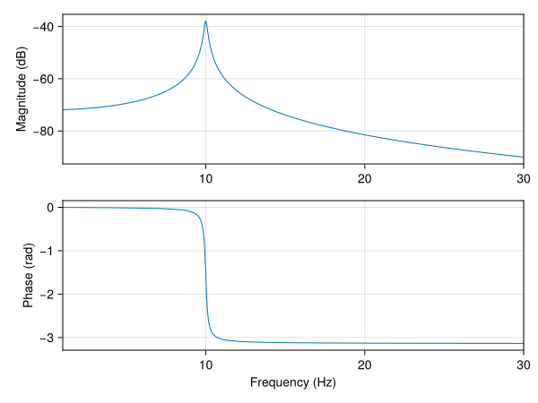

```julia
# Initialize a Sdof type
m = 1.
f0 = 10.
ξ = 0.01
sdof = Sdof(m, f0, ξ)

# Computation parameters
freq = 1.:0.01:30.

# Compute the FRF
prob_frf = SdofFRFProblem(sdof, freq)
H = solve(prob_frf).u

# Bode plot
bode_plot(freq, H)
```

## 2 Nyquist plot

The Nyquist plot is either a 2D or 3D plot. In 2D, it is a graph of the imaginary part versus the real part of the transfer function. In 3D, it is a graph of the imaginary part versus the real part of the transfer function and the frequency.

### 2.1 2D plot

**nyquist_plot**

```
nyquist_plot(y)
```

Plot Nyquist diagram

**Inputs**

- `y`: Complex data vector

**Output**

- `fig`: Figure

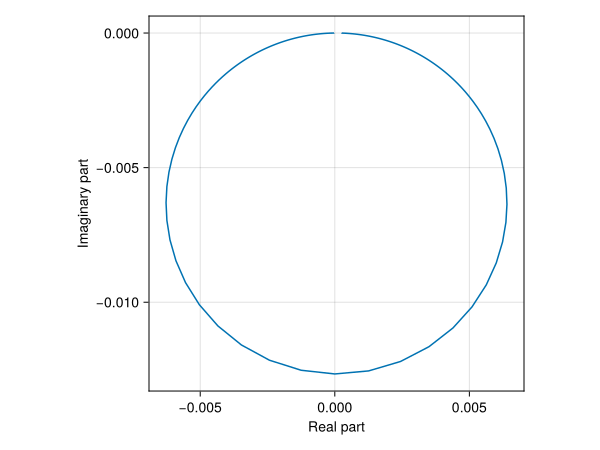

```julia
nyquist_plot(H)
```

### 2.2 3D plot

**nyquist_plot**

```
nyquist_plot(freq, y, xlab = "Frequency (Hz)";
             projection = false)
```

Plot Nyquist diagram in 3D

**Inputs**

- `freq`: Frequency range

- `y`: Complex vector

- `projection`: Projection of the curve on the xy, yz, and xz planes (default: false)

  - on the xy plane: (freq, real(y))

  - on the yz plane: (imag(y), freq)

  - on the xz plane: (real(y), imag(y))

**Output**

- `fig`: Figure

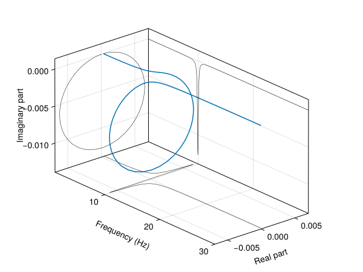

```julia
nyquist_plot(freq, H, projection = true)
```

## 3 Waterfall plot

A waterfall plot is a 3D plot with a partial curtain along the y-axis.

**waterfall_plot**

```
waterfall_plot(x, y, z; zmin = minimum(z), lw = 1.,
               colorline = :auto, colmap = :viridis, colorband = (:white, 1.),
               xlabel = "x", ylabel = "y", zlabel = "z", edge = true,
               axis_tight = false, xlim = [minimum(x), maximum(x)],
               ylim = [minimum(y), maximum(y)], zlim = [zmin, maximum(z)])
```

Plot a waterfall plot.

**Inputs**

- `x`: x-axis values

- `y`: y-axis values

- `z`: z-axis values

- `zmin`: minimum value of z-axis

- `lw::Real`: linewidth

- `colorline`: color of the lines

- `colmap`: Name of the colormap

- `colorband`: Tuple defining the color of the band

  - color : Color

  - alpha : Alpha value for transparency

- `xlabel`: x-axis label

- `ylabel`: y-axis label

- `zlabel`: z-axis label

- `edge`: Display edges (default: true)

- `axis_tight`: Tight axis (default: false)

- `xlim`: x-axis limits

- `ylim`: y-axis limits

- `zlim`: z-axis limits

**Output**

- `fig`: Figure

```julia
x = range(0., 2π, 100)
y = range(0., 1., 5)

nx = length(x)
ny = length(y)
z = zeros(ny, nx)

for i in eachindex(y)
    z[i, :] = sin.(i*x/2.)
end

waterfall_plot(x, y, z, xlim = [-0.1, 2π + 0.1], ylim = [-0.1, 1.1])
```

[figure not shown]

## 4 Stabilization plot

The stabilization plot is used in the context of the modal analysis to plot the Stabilization diagram.

**stabilization_plot**

```
stabilization_plot(stab::StabilizationAnalysis, indicator; display_poles)
```

Plot stabilization diagram for EMA-MDOF pole stability analysis.

**Inputs**

- `stab`: EMA-MDOF stabilization data

- `indicator`: Indicator to plot

  - `:psif` : Power spectrum indicator function (default)

  - `:cmif` : Complex mode indicator function

- `display_poles`: Vector of Bool to choose which poles to display

  - `display_poles[1]` : Stable in frequency and damping (default: true)

  - `display_poles[2]` : Stable in frequency but not stable in damping (default: true)

  - `display_poles[3]` : Not stable in frequency (default: true)

**Output**

- `fig`: Figure

Examples of stabilization plot can be found in the Modal extraction documentation.

## 5 Peaks plot

The peaks plot is used to visualize the peak detection of a given function. It is a useful tool to define the parameters of the peak detection algorithm use to extract the poles using Sdof methods.

**peaks_plot**

```
peaks_plot(x, y; width = 5, min_prom = 0., max_prom = Inf,
          xlabel = "x", ylabel = "y")
```

Plot data with detected peaks.

**Inputs**

- `x`: x-axis values

- `y`: y-axis values

- `min_prom`: Minimum peak prominence (default: 0.)

- `max_prom`: Maximum peak prominence (default: Inf)

- `xlabel`: x-axis label

- `ylabel`: y-axis label

**Output**

- `fig`: Figure

- `pks`: Detected peaks

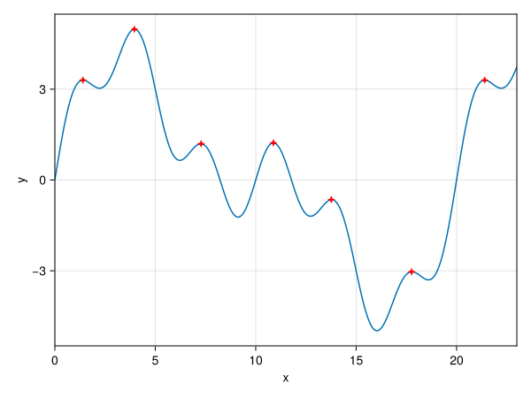

```julia
# Signal used in Peaks.jl package documentation
T = 1/25
t = 0:T:23

y = 3sinpi.(0.1t) + 2sinpi.(0.2t) + sinpi.(0.6t)
peaks_plot(t, y)
```